# Report 3 - Vaccination externalities

Daniela Olivera

### The system

The system is three patch meta-population model. Each patch has its own disease dynamics (SIS o SIR) and is interconnected, as shown below.

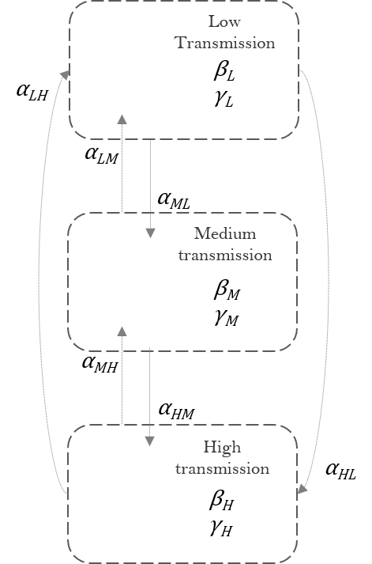

//

**Setting up the model parameters for the model:**

1. Number of patches: *npop*
2. Population in each patch: *N*
3. Individual Ro: *ro* → 1.5 - 5 - 15
4. Patch recovery rate: *rec*
5. Interaction matrix between patches: **Rows of the marix must sum 1**
   $$\mathbf{\alpha } = \left[\begin{array}
   {rrr}
   \alpha_{LL} & \alpha_{LM} & \alpha_{LH} \\
   \alpha_{ML} & \alpha_{MM} & \alpha_{MH} \\
   \alpha_{HL} & \alpha_{HM} & \alpha_{HH}
   \end{array}\right]$$

```r
# General parameters for all the models
npop <- 3
N <- c(1e6, 1e6, 1e6)
rec <- c(0.5, 0.5, 0.5)
ro <- c(1.5,5,15)
alpha <-  matrix(c(0.95, 0.02, 0.03, 0.02, 0.96, 0.02, 0.03, 0.02, 0.95),  nrow = 3,ncol = 3, byrow = TRUE)
ef<- 1
I0 <- c(1, 1, 1)

#Time
tt <- seq(0, 100, length.out = 201)
```

### 1. Next generation matrix (NGM)

$$\mathbf{NGM } = \left[\begin{array}
{rrr}
\frac{\beta_L \alpha_{LL}}{\gamma_L} & \frac{\beta_L \alpha_{LM}}{\gamma_M} & \frac{\beta_L \alpha_{LH}}{\gamma_H} \\
\frac{\beta_M \alpha_{ML}}{\gamma_L} & \frac{\beta_M \alpha_{MM}}{\gamma_M} & \frac{\beta_M \alpha_{MH}}{\gamma_H} \\
\frac{\beta_H \alpha_{HL}}{\gamma_L} & \frac{\beta_H \alpha_{HM}}{\gamma_M} & \frac{\beta_H \alpha_{HH}}{\gamma_H}
\end{array}\right]$$

The problem with the NGM was in the parametrisation. In the $\alpha$ matrix each entry “measures the relative strength of transmission to sub population *i* to sub population *j*” and I was assuming $\alpha_{ii} =1$ Therefore the total relative strength of transmission in each patch was higher than one

After I changed the parameters and the code, the Ro value for the three patch model is **14.2547737**

### 2. Coverage screening and bug in solver:

- I managed to find the bug in the equations solvers and now the solver works for any set of parameters I’ve tried so far.
- I did the screening instead of the optimisation algorithm and it runs smoothly. I am having trouble on how to plot the results in a nice way.
- So far the screening evaluates Ro and the fraction of cases averted with SIS and SIR model. The results are saved on a data frame like the one below.

```r
vec_cov <- seq(0,1,0.05)

C <- cov_screening (vec_cov, alpha, rec, ro, N,ef, I0)


Vmax <- 2.2e6

sub <- subset(C,(C[,1]*N[1]+ C[,2]*N[2]+ C[,3]*N[3])<Vmax)

newdata <- sub[order(sub[,4]),]
```

```r
print.data.frame(head(newdata))
```

```
##        CL   CM   CH        Ro       SIS       SIR
## 8744 0.35 0.85 0.95 0.9309577 1.0000000 0.9999900
## 8724 0.40 0.80 0.95 0.9651502 1.0000000 0.9999827
## 9164 0.35 0.80 1.00 0.9691013 1.0000000 0.9999808
## 8723 0.35 0.80 0.95 0.9718523 1.0000000 0.9999764
## 9184 0.30 0.85 1.00 0.9986305 1.0000000 0.9999764
## 8764 0.30 0.90 0.95 1.0004310 0.9998421 0.9999733
```

### 3. Vaccine externalities (Boulier et al (2007) Paper)

```r
source("../Vaccination_externalities.R")
```

Here is a table with the most used terms on the paper that are needed to calculate vaccination externalities:

| Term | Symbol | Definition |
| --- | --- | --- |
| Cost of the disease | *k* | Cost an individual incurs if infected |
| Probability of infection | *p(V)* | Probability of becoming infected given that V people are vaccinated |
| Vaccine effectiveness | *m* | Vaccine effectiveness |
| Marginal effect of a vaccination | MEV | Number of cases averted per each additional vaccine: $\frac{\Delta AvertedCases} {\Delta Vaccines}$ |
| Marginal social benefit | MSB | Net social value of vaccination |
| Marginal private benefit | MPB | The difference between the expected costs of the disease with and without vaccination. (Direct protection in epidemiology) |
| Vaccination externalities | ME | The difference between MSB and MPB (The indirect protection in epidemiology) |

#### Asumptions:

- Vaccines are distributed equally among the three patches.
- Vaccinations are purchased and administrated before the model is run.
- All simulation were run with 100% vaccine effectiveness (however the code now allows to change this)
- $k =1$

### 1. Marginal social benefits of vaccination:

1.1 The first step to estimate MSB is to find the MEV. This is the number of cases averted per each additional vaccination.

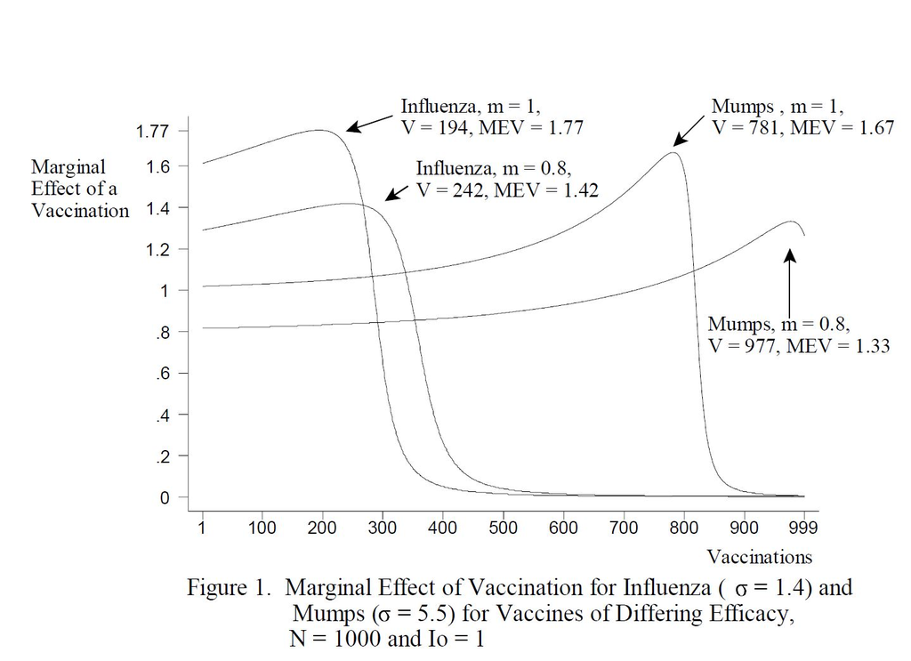

//

For the meta-population model different behaviours are seen for SIS and SIR models as well as the different transmission intensities.

**Note: At the moment I am plotting every 100 additional vaccines. Maybe the peaks would be smoother with a smaller step but it takes a long time computing**

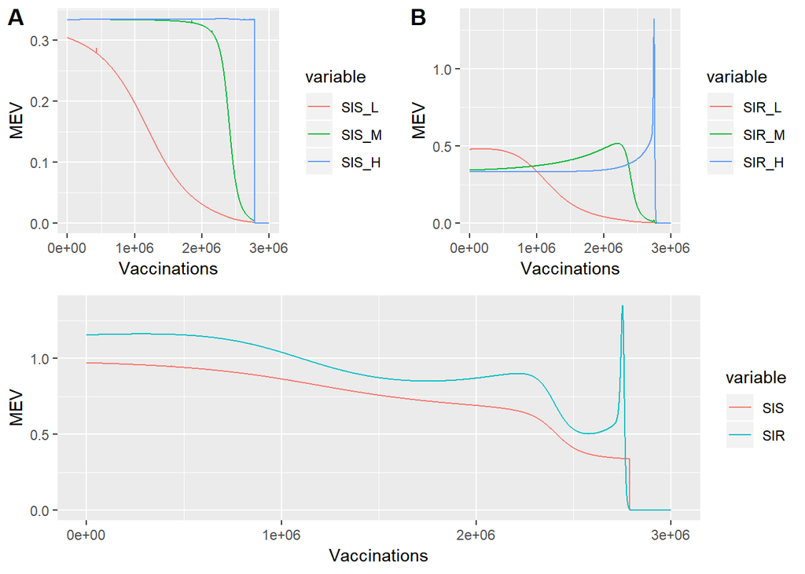

1.2 The Marginal Social benefit is $MSB = MEV * k$. At the moment k is set as 1, consequently the MEV and MSB graphs are the same.

### 2. Marginal private benefits of vaccination:

Boulier et al. define the marginal private benefit as the difference between the cost of the disease and the expected cost of the disease if the individual is vaccinated.

$$MPB = p(V)k - (1-m) p(V) k = m p(V) k$$
Where $p(V)$ is the probability of being infected given that V people are vaccinated.

//

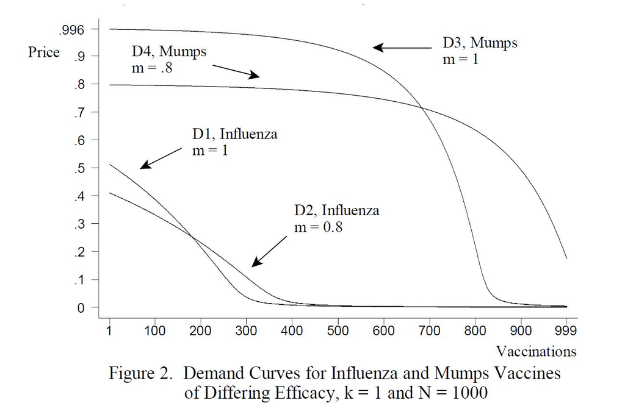

// //

$$p(V) = \frac{Total Infections - Initial Infections} {Initial Susceptible Population} = \frac{Total infecions - I_o} {N- mV- I_o}$$
**Comments:**

- I used the same approach to estimate de probability of infection but I think it is not the same probability of infection used in epidemiology.
- They called the MPB curve a demand curve. I haven’t been able to understand why they called it like that.

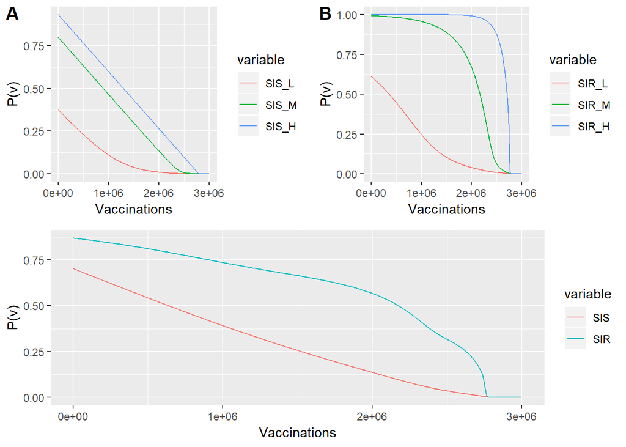

Since we are assuming that $k=1$ and the vaccine efficiency is 100% the MPB and PEV graphs are the same.

### 3. Vaccination externalities

The vaccination externalities is just the difference between the MSB and MPB curves.

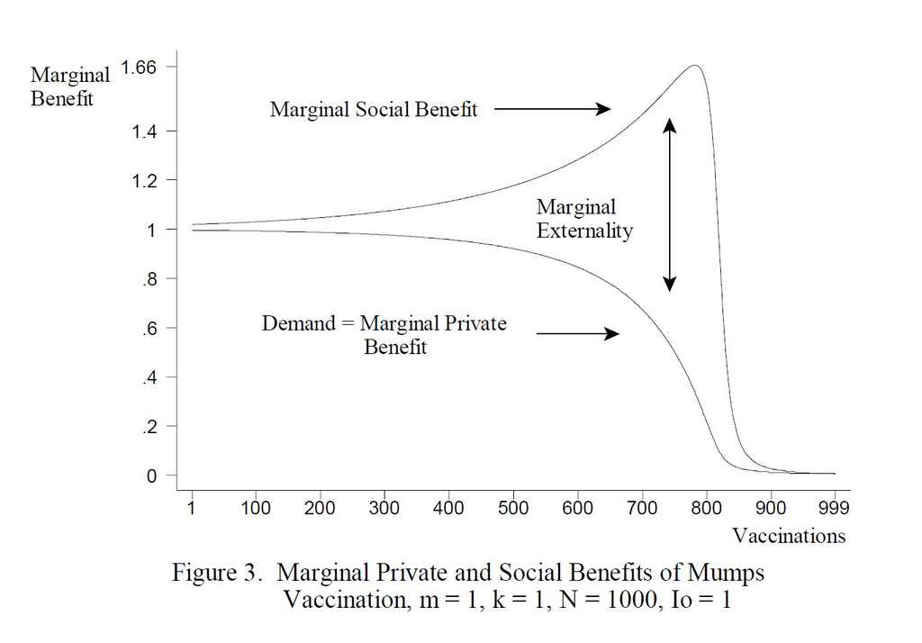

With the meta-population patch model:

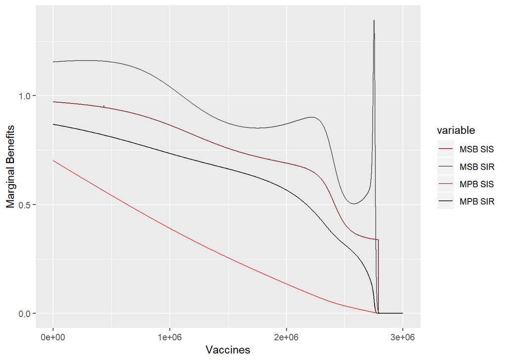

```r
try <-  cbind(MEV[2:length(vaccine) ,c(1,5,9)],pv_out[ 2:length(vaccine),c(5,9)] )
colnames(try) <- c("Vaccine", "MSB SIS", "MSB SIR", "MPB SIS", "MPB SIR")
try_long <- melt(try, id.vars = "Vaccine")
p <- ggplot(try_long, aes(x = Vaccine, y = value , col = variable)) + geom_line()+ xlab("Vaccines") + ylab("Marginal Benefits")+scale_color_manual(values=c("brown4", "gray35", "brown2", "gray1"))
p
```